# Modelos Geoestatísticos para Previsão de PCB-138 na Plataforma Continenal Holandesa

# **1.Introdução**

O banco de dados utilizado neste estudo contém informações sobre concentrações de PCB138 em pontos localizados na Plataforma Continental Holandesa, que é a parte holandesa do mar do norte na Europa. Cada observação inclui as coordenadas x e y e os valores de concentração do composto, registrados em diferentes locais dessa área.  
PCB138 é um dos muitos congêneres de *bifenilos policlorados* (PCBs), que são compostos químicos sintéticos amplamente utilizados no passado em indústrias devido à sua estabilidade térmica, química e elétrica.  
A partir desses dados dois modelos geoestatísticos foram propropostos: um sem covariável e outro com duas covariáveis descritas nas seções a seguir.

[figure not shown]

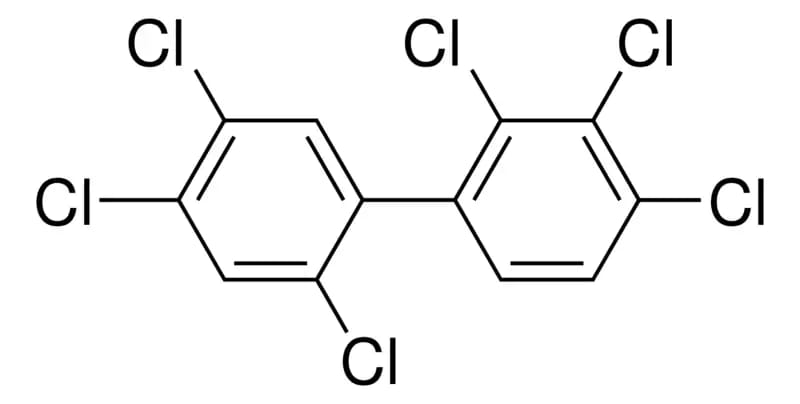

# **2.Visualização do Banco**

- **year**: ano da medição
- **x**: coordenada x
- **y**: coordenada y
- **coast**: distância até à costa da Holanda, em quilômetros.
- **depth**: profundidade da água do mar em metros.
- **PCB138**: PCB138, medido na fração de sedimentos menor que 63 micrômetros.
- **yf**: ano da medição como fator.

```r
data("pcb")
data("ncp.grid")
```

```r
kable(head(pcb))
```

|  | year | x | y | coast | depth | PCB138 | yf |
| --- | --- | --- | --- | --- | --- | --- | --- |
| 77 | 1986 | 595484.7 | 5785807 | 1 | 16.549030 | 5.4 | 1986 |
| 78 | 1986 | 593197.6 | 5782240 | 3 | 16.545622 | 8.0 | 1986 |
| 79 | 1986 | 590442.5 | 5779130 | 4 | 17.701961 | 10.1 | 1986 |
| 80 | 1986 | 582090.7 | 5768014 | 2 | 12.402394 | 9.7 | 1986 |
| 81 | 1986 | 581529.8 | 5768530 | 2 | 9.859355 | 5.6 | 1986 |
| 82 | 1986 | 674930.4 | 5929092 | 2 | 13.982552 | 4.4 | 1986 |

```r
str(pcb)
```

```
## 'data.frame':    216 obs. of  7 variables:
##  $ year  : int  1986 1986 1986 1986 1986 1986 1986 1986 1986 1986 ...
##  $ x     : num  595485 593198 590443 582091 581530 ...
##  $ y     : num  5785807 5782240 5779130 5768014 5768530 ...
##  $ coast : num  1 3 4 2 2 2 21 2 66 3 ...
##  $ depth : num  16.55 16.55 17.7 12.4 9.86 ...
##  $ PCB138: num  5.4 8 10.1 9.7 5.6 4.4 8 4 4.1 9.6 ...
##  $ yf    : Factor w/ 7 levels "1986","1987",..: 1 1 1 1 1 1 1 1 1 1 ...
##  - attr(*, "na.action")= 'omit' Named int [1:81] 1 2 3 4 5 6 7 8 9 10 ...
##   ..- attr(*, "names")= chr [1:81] "1" "3" "5" "6" ...
```

```r
df <- pcb
coordinates(df) <- ~x+y
class(df)
```

```
## [1] "SpatialPointsDataFrame"
## attr(,"package")
## [1] "sp"
```

Visualização dos pontos:

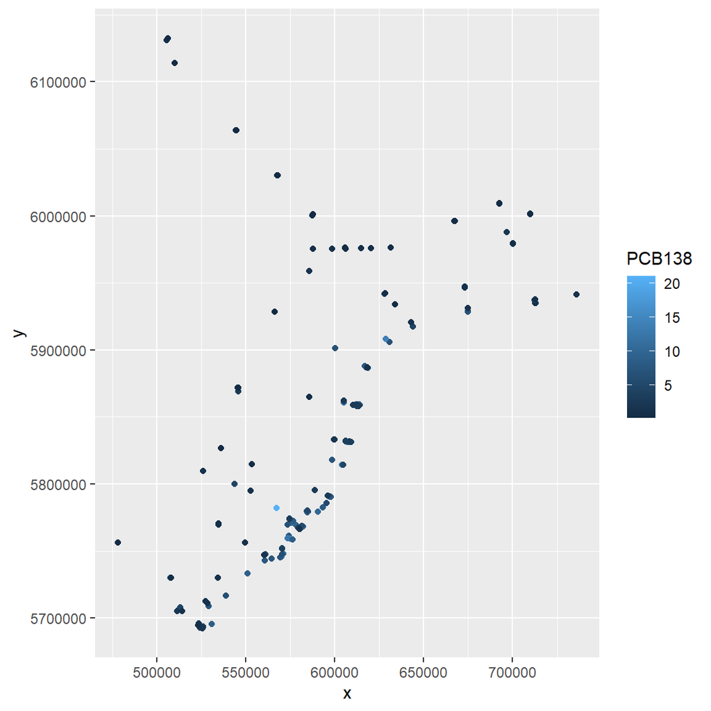

```r
ggplot(data.frame(df))+
  geom_point(aes(x=x, y=y, color= PCB138))
```

Grid onde os valores serão preditos:

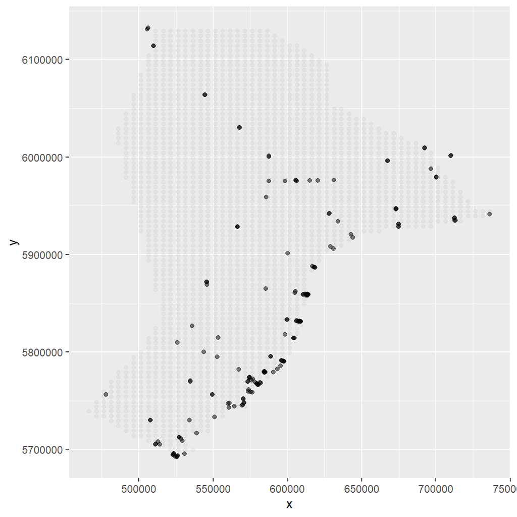

```r
df_grid <- ncp.grid
gridded(df_grid) <- ~x + y # transforma na classe sp
proj4string(df_grid) <- CRS("+init=epsg:28992") # indicar o tipo de projeção para o mapview
proj4string(df) <- CRS("+init=epsg:28992")

ggplot(data.frame(df_grid))+
  geom_point(aes(x=x, y=y), color = "grey", alpha=0.2)+
  geom_point(aes(x=x, y=y), alpha = 0.5, data = data.frame(df))
```

Vizualização uilizando LEAF:

```r
# coordenadas em sistema UTM Zone 31
ncp_sf <- st_as_sf(ncp.grid, coords = c("x", "y"), crs = 32631)


ncp_sf <- st_transform(ncp_sf, crs = 4326)


leaflet(data = ncp_sf) %>%
  addTiles() %>%
  addCircleMarkers(
    color = ~colorNumeric("viridis", depth)(depth),
    popup = ~paste("Profundidade:", depth),
    radius = 5
  ) %>%
  addLegend(
    "bottomright",
    pal = colorNumeric("viridis", ncp_sf$depth),
    values = ncp_sf$depth,
    title = "depth",
    opacity = 1
  )
```

[interactive chart not shown]

```r
# coordenadas em sistema UTM Zone 31
pcb_sf <- st_as_sf(pcb, coords = c("x", "y"), crs = 32631)


pcb_sf <- st_transform(pcb_sf, crs = 4326)


leaflet(data = pcb_sf) %>%
  addTiles() %>%
  addCircleMarkers(
    color = ~colorNumeric("viridis", PCB138)(PCB138),
    popup = ~paste("PCB138:", PCB138),
    radius = 5
  ) %>%
  addLegend(
    "bottomright",
    pal = colorNumeric("viridis", pcb_sf$PCB138),
    values = pcb_sf$PCB138,
    title = "PCB138",
    opacity = 1
  )
```

[interactive chart not shown]

# **3. Krigagem**

Utilizaremos como variável resposta a concentração de PCB-138 no mar.  
Plotando o histograma da variável:

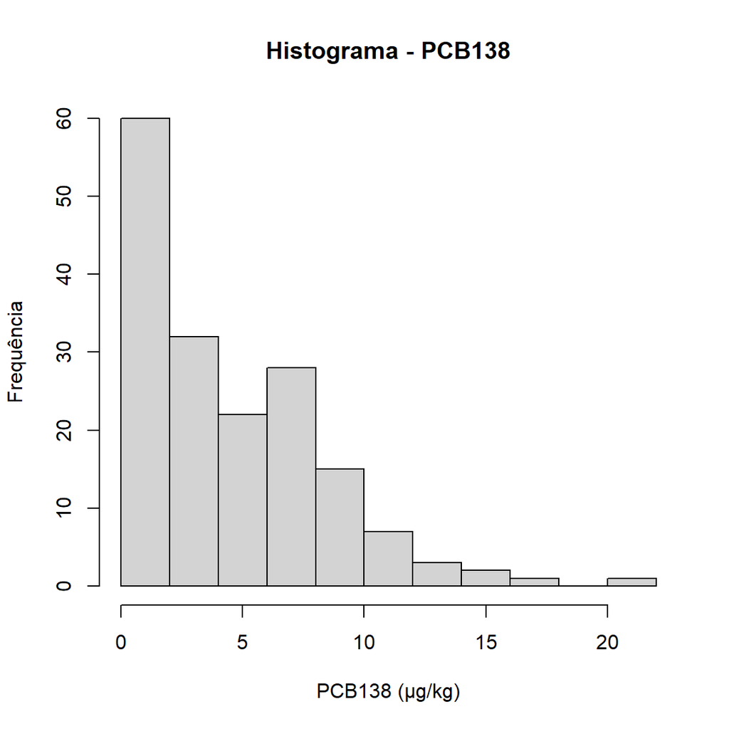

```r
hist(df$PCB138, xlab = "PCB138 (µg/kg)", ylab = "Frequência", main = "Histograma - PCB138")
```

O histograma apresenta forte assimetria. Aplcaremos o log para tentarmos modelar assumindo a normalidade da variável resposta.

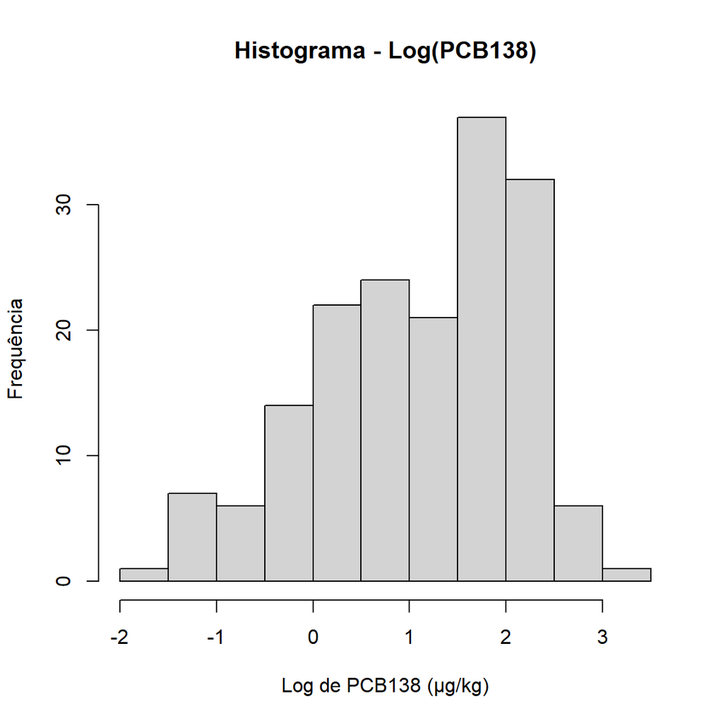

```r
hist(log(df$PCB138), xlab = "Log de PCB138 (µg/kg)", ylab = "Frequência", main = "Histograma - Log(PCB138)")
```

Com a transformação, pelo histograma, assumiremos normalidade.

Estimação do variograma:

```r
variograma <- variogram(log(PCB138) ~ 1, locations = ~x + y, data = data.frame(df))

kable(variograma)
```

| np | dist | gamma | dir.hor | dir.ver | id |
| --- | --- | --- | --- | --- | --- |
| 611 | 4769.566 | 0.3444949 | 0 | 0 | var1 |
| 576 | 16804.996 | 0.3472053 | 0 | 0 | var1 |
| 777 | 28158.801 | 0.4681358 | 0 | 0 | var1 |
| 592 | 40434.237 | 0.6497647 | 0 | 0 | var1 |
| 597 | 51259.738 | 0.7061266 | 0 | 0 | var1 |
| 670 | 63002.075 | 0.8102368 | 0 | 0 | var1 |
| 965 | 72868.200 | 1.0436208 | 0 | 0 | var1 |
| 721 | 84625.326 | 1.0283310 | 0 | 0 | var1 |
| 1005 | 95659.424 | 0.7960591 | 0 | 0 | var1 |
| 624 | 107290.527 | 1.0040056 | 0 | 0 | var1 |
| 752 | 119203.565 | 1.0210243 | 0 | 0 | var1 |
| 377 | 129901.417 | 0.8256483 | 0 | 0 | var1 |
| 509 | 143154.891 | 1.1936975 | 0 | 0 | var1 |
| 427 | 152042.462 | 1.0519547 | 0 | 0 | var1 |
| 502 | 163809.719 | 1.0541187 | 0 | 0 | var1 |

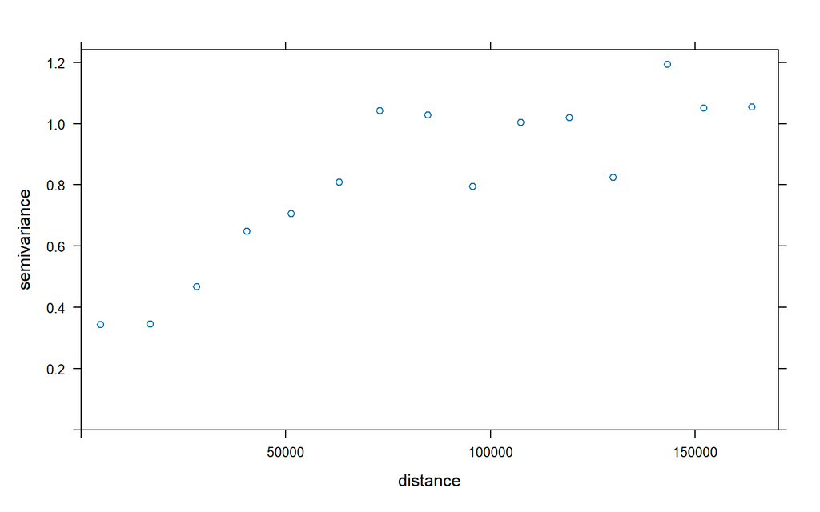

```r
plot(variograma)
```

```r
#Variograma Gaussiano
fit.gau <- fit.variogram(variograma, vgm(1.0, "Gau", 75000))
```

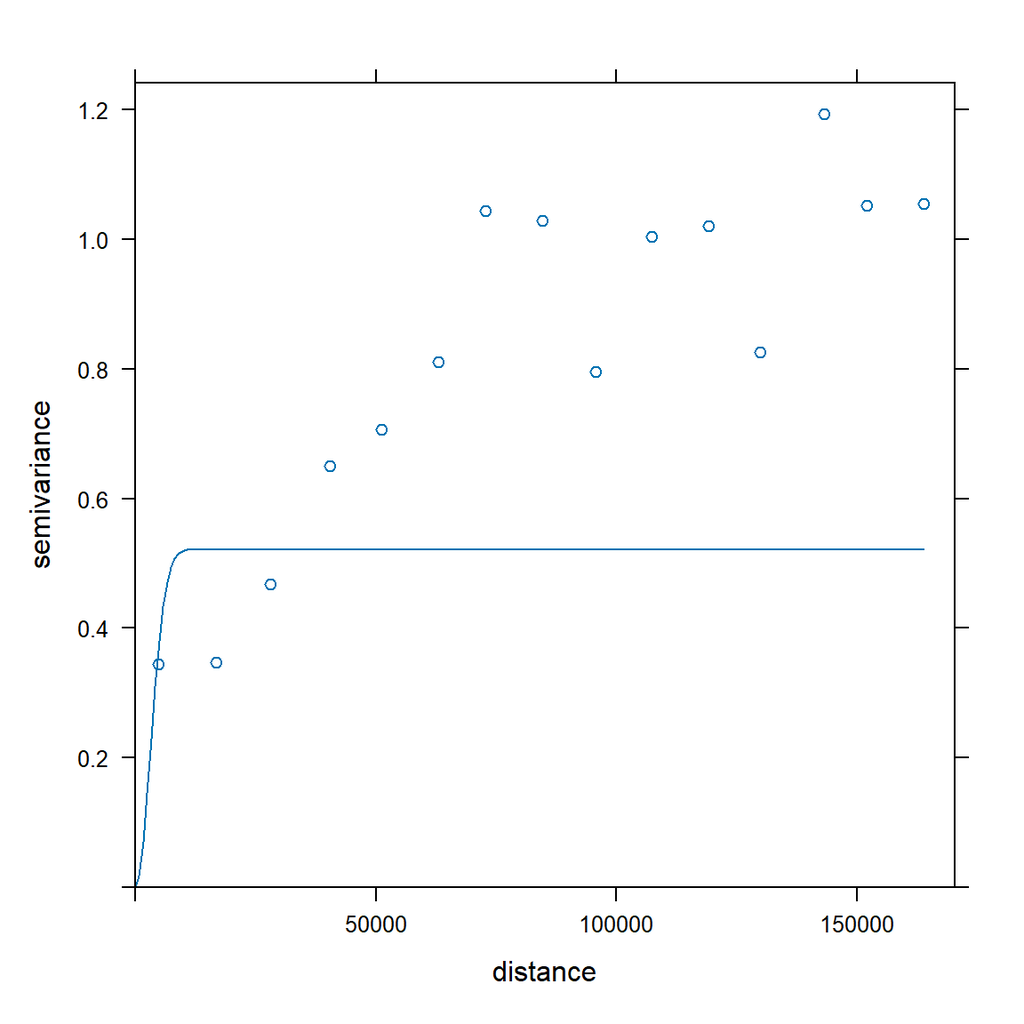

```r
plot(variograma, fit.gau)
```

Suavizando o Efeito Pepita (Nugget) no variograma e plotando alguns modelos:

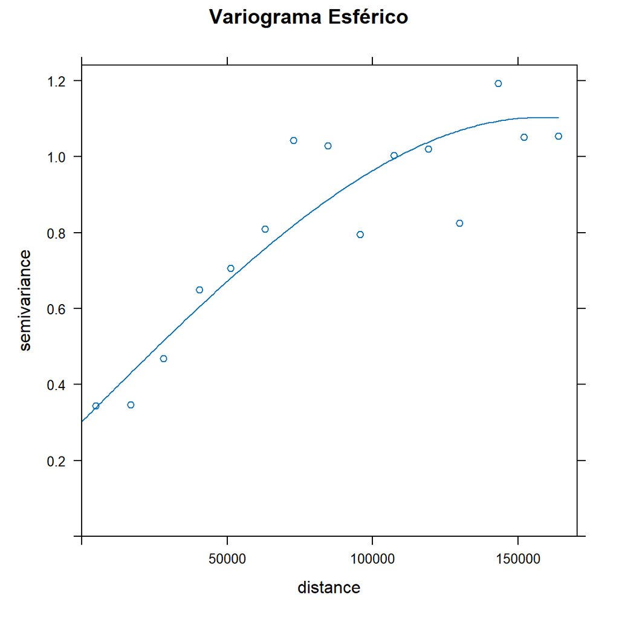

```r
fit.sph <- fit.variogram(variograma, vgm(1.0, "Sph", 60000, nugget = 0.1))
fit.gau <- fit.variogram(variograma, vgm(1.0, "Gau", 75000, nugget = 0.1))
fit.exp <- fit.variogram(variograma, vgm(1.0, "Exp", 50000, 0.1))
par(mfrow = c(1, 3)) # 1 linha e 3 colunas


plot(variograma, fit.sph, main = "Variograma Esférico")
```

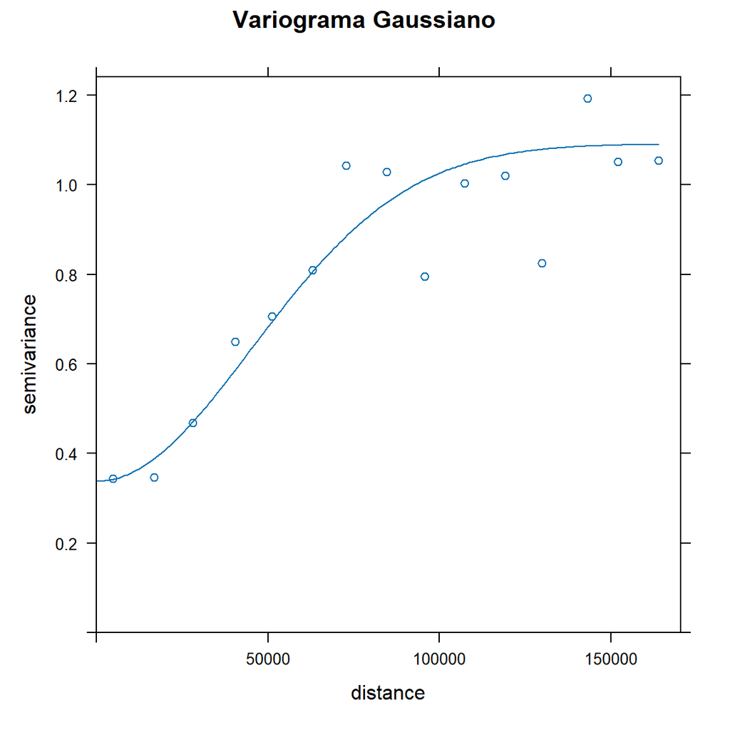

```r
plot(variograma, fit.gau, main = "Variograma Gaussiano")
```

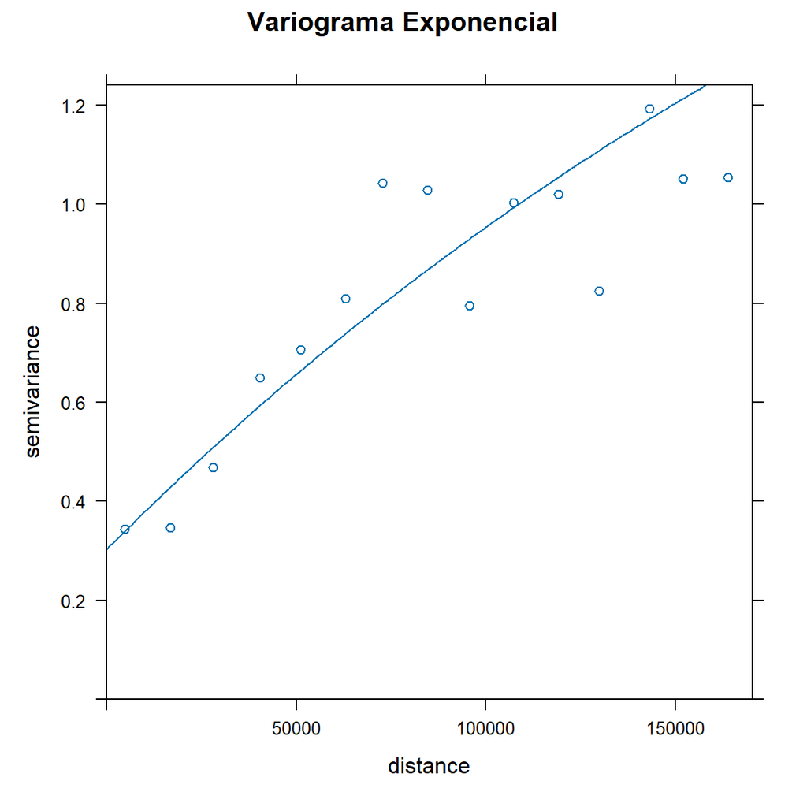

```r
plot(variograma, fit.exp, main = "Variograma Exponencial")
```

[figure not shown]

```r
fit.sph <- fit.variogram(variograma, model = vgm(psill = 1.0, model = "Sph", range = 60000, nugget = 0.1))
#fit.sph
plot(variograma, model = fit.sph, main = "Variograma Esférico")
```

[figure not shown]

```r
fit.gau <- fit.variogram(variograma, model = vgm(psill = 1.0, model = "Gau", range = 75000, nugget = 0.1))
plot(variograma, model = fit.gau, main = "Variograma Gaussiano")
```

## **3.1 Krigagem Ordinária**

Modelo assumindo média desconhecida e constante.

```r
dados_krig_ordinaria <- krige(log(PCB138) ~ 1, df, df_grid, model = fit.gau1)
```

```
## [using ordinary kriging]
```

```r
names(dados_krig_ordinaria)
```

```
## [1] "var1.pred" "var1.var"
```

```r
class(dados_krig_ordinaria)
```

```
## [1] "SpatialPixelsDataFrame"
## attr(,"package")
## [1] "sp"
```

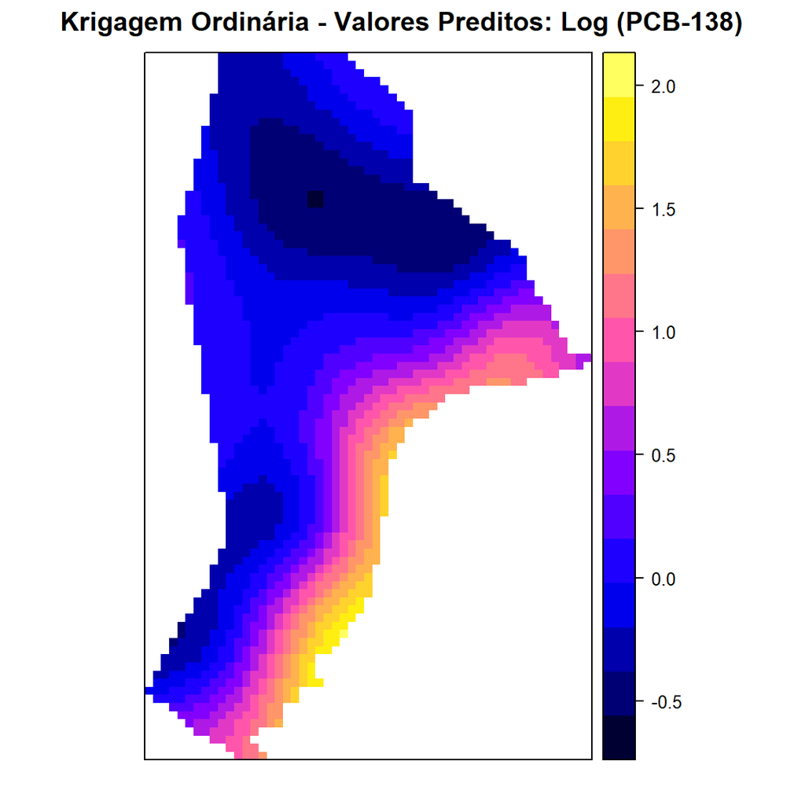

```r
p1pred <- spplot(dados_krig_ordinaria["var1.pred"], main = "Krigagem Ordinária - Valores Preditos: Log (PCB-138)")
p1pred
```

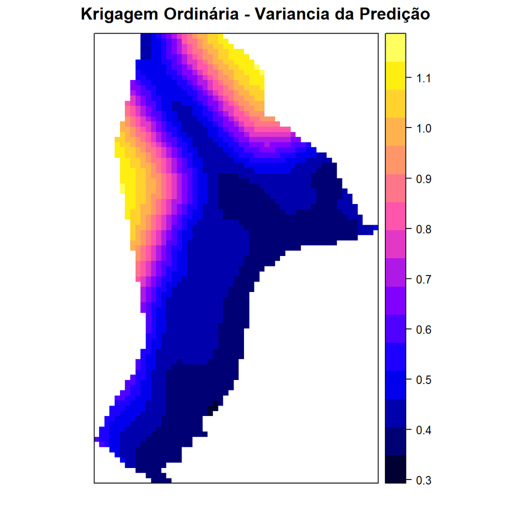

```r
p1var <- spplot(dados_krig_ordinaria["var1.var"], main = "Krigagem Ordinária - Variancia da Predição")
p1var
```

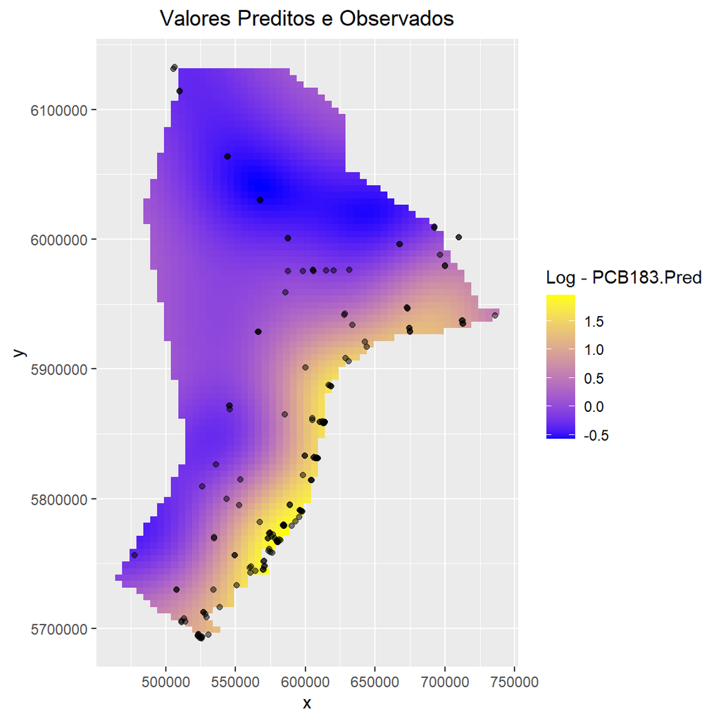

```r
plot_media_ordinaria <- ggplot(data.frame(dados_krig_ordinaria)) +
  geom_tile(aes(x = x, y = y, fill = var1.pred)) +
  scale_fill_gradient(low = "blue", high = "yellow") +
  geom_point(aes(x = x, y = y), alpha = 0.5, data = data.frame(df)) +
  labs(fill = "Log - PCB183.Pred", title = "Valores Preditos e Observados") +
  theme(plot.title = element_text(hjust = 0.5))

plot_media_ordinaria
```

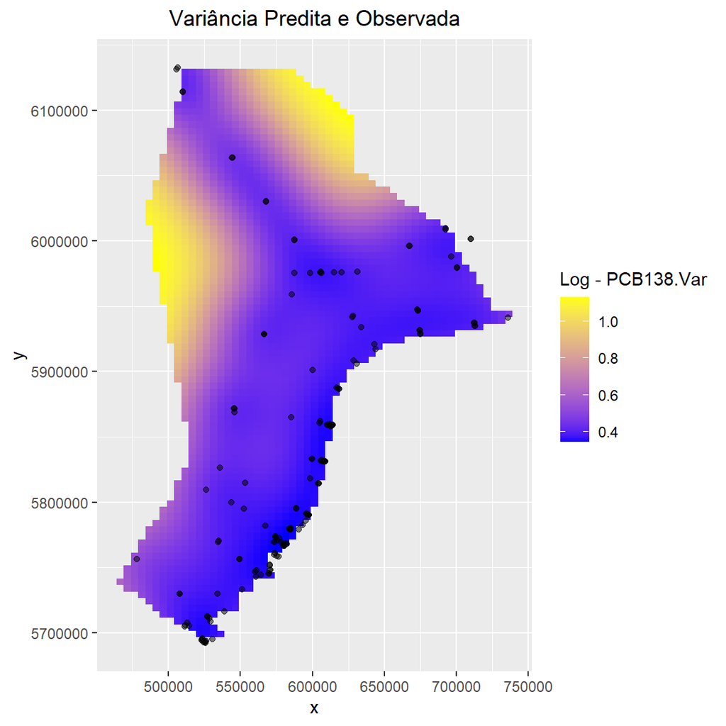

```r
plot_variancia_ordinaria <- ggplot(data.frame(dados_krig_ordinaria)) +
  geom_tile(aes(x = x, y = y, fill = var1.var)) +
  scale_fill_gradient(low = "blue", high = "yellow") +
  geom_point(aes(x = x, y = y), alpha = 0.5, data = data.frame(df)) +
  labs(fill = "Log - PCB138.Var", title = "Variância Predita e Observada") +
  theme(plot.title = element_text(hjust = 0.5)) # Centraliza o título

plot_variancia_ordinaria
```

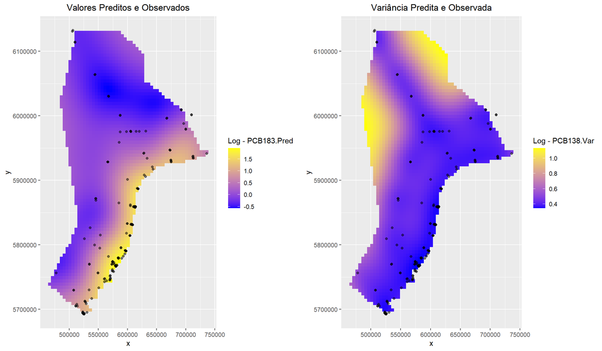

```r
grid.arrange(plot_media_ordinaria, plot_variancia_ordinaria, ncol=2)
```

## **3.2 Krigagem Universal**

Modelo assumindo média variável, como uma função do espaço.

```r
summary(lm(log(PCB138) ~ depth + coast, data = df))
```

```
##
## Call:
## lm(formula = log(PCB138) ~ depth + coast, data = df)
##
## Residuals:
##     Min      1Q  Median      3Q     Max
## -2.1681 -0.5414  0.1461  0.5667  1.9024
##
## Coefficients:
##              Estimate Std. Error t value Pr(>|t|)
## (Intercept)  2.368555   0.193798  12.222  < 2e-16 ***
## depth       -0.053203   0.010705  -4.970 1.64e-06 ***
## coast       -0.006200   0.001917  -3.233  0.00147 **
## ---
## Signif. codes:  0 '***' 0.001 '**' 0.01 '*' 0.05 '.' 0.1 ' ' 1
##
## Residual standard error: 0.7618 on 168 degrees of freedom
## Multiple R-squared:  0.4538, Adjusted R-squared:  0.4473
## F-statistic: 69.78 on 2 and 168 DF,  p-value: < 2.2e-16
```

As variáveis “depth” e “coast” foram significativas ao nível alfa de **5%**.

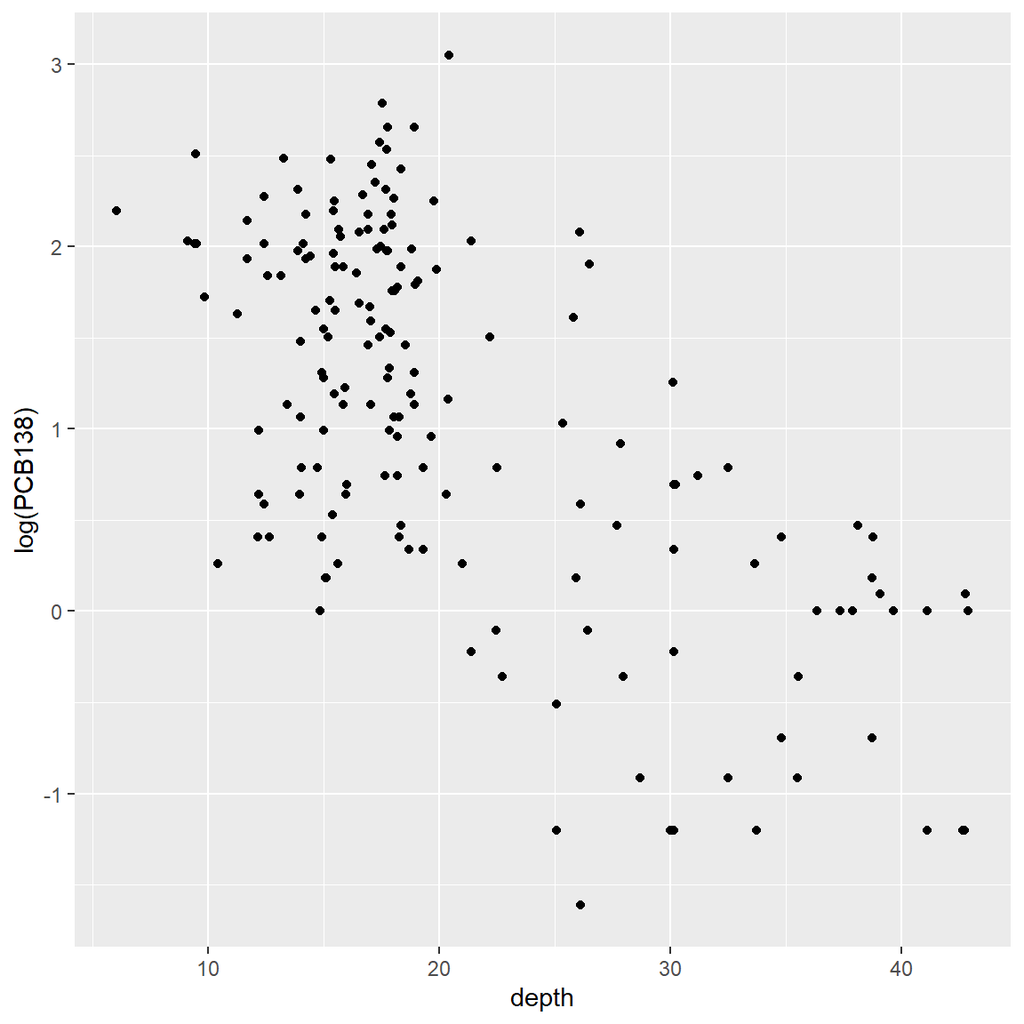

```r
ggplot(data.frame(df))+
  geom_point(aes(x=depth, y=log(PCB138)))
```

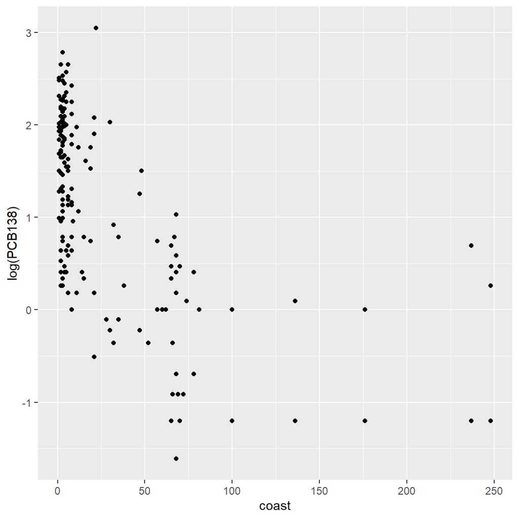

```r
ggplot(data.frame(df))+
  geom_point(aes(x=coast, y=log(PCB138)))
```

Variograma Considerando as Covariáveis:

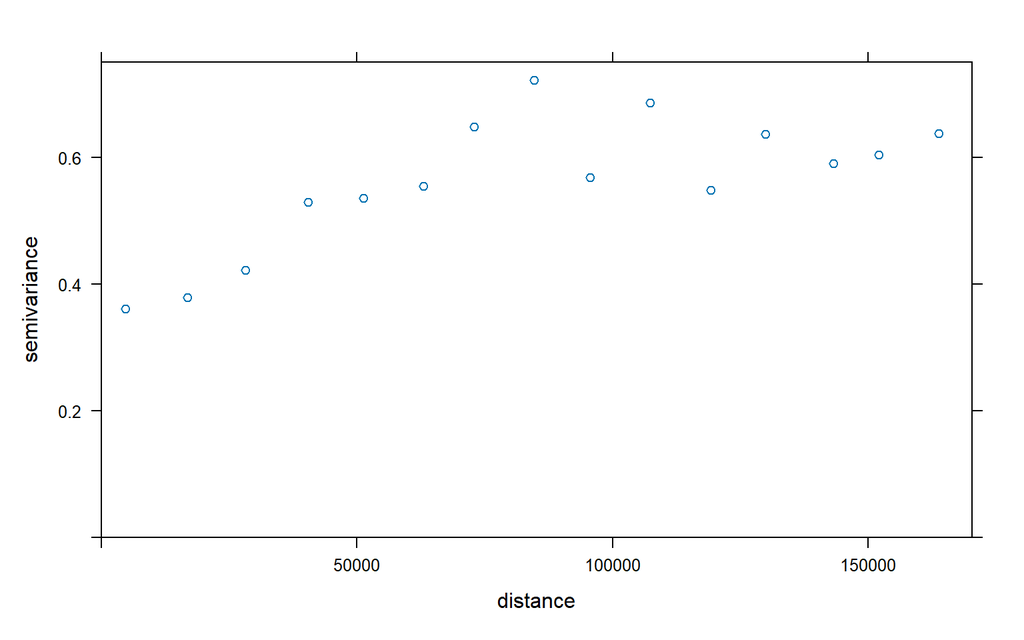

```r
variograma_com_covariavel <- variogram(log(PCB138) ~ depth + coast, data = df)
plot(variograma_com_covariavel)
```

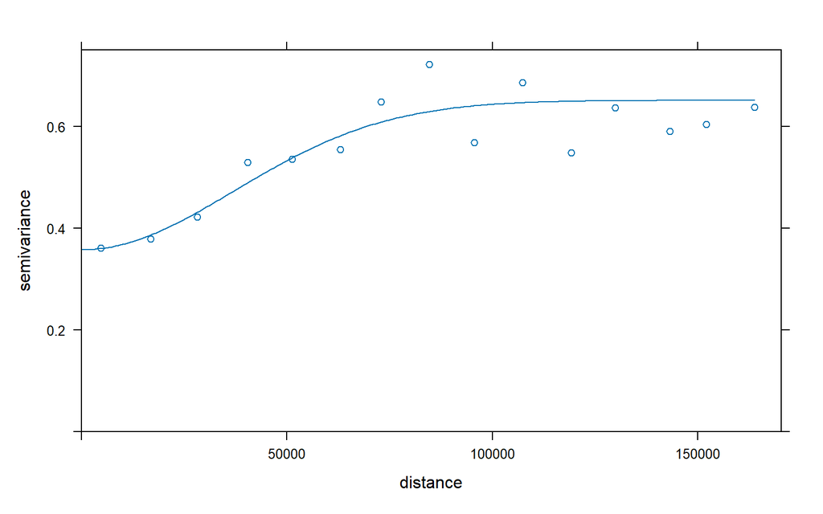

```r
ajuste_esf_variograma_com_covariavel = fit.variogram(variograma_com_covariavel, vgm(0.6, "Gau", 75000, 0.5))

plot(variograma_com_covariavel, ajuste_esf_variograma_com_covariavel)
```

```r
dados_krigagem_universal <- krige(log(PCB138) ~ depth + coast, df, df_grid, model = ajuste_esf_variograma_com_covariavel)
```

```
## [using universal kriging]
```

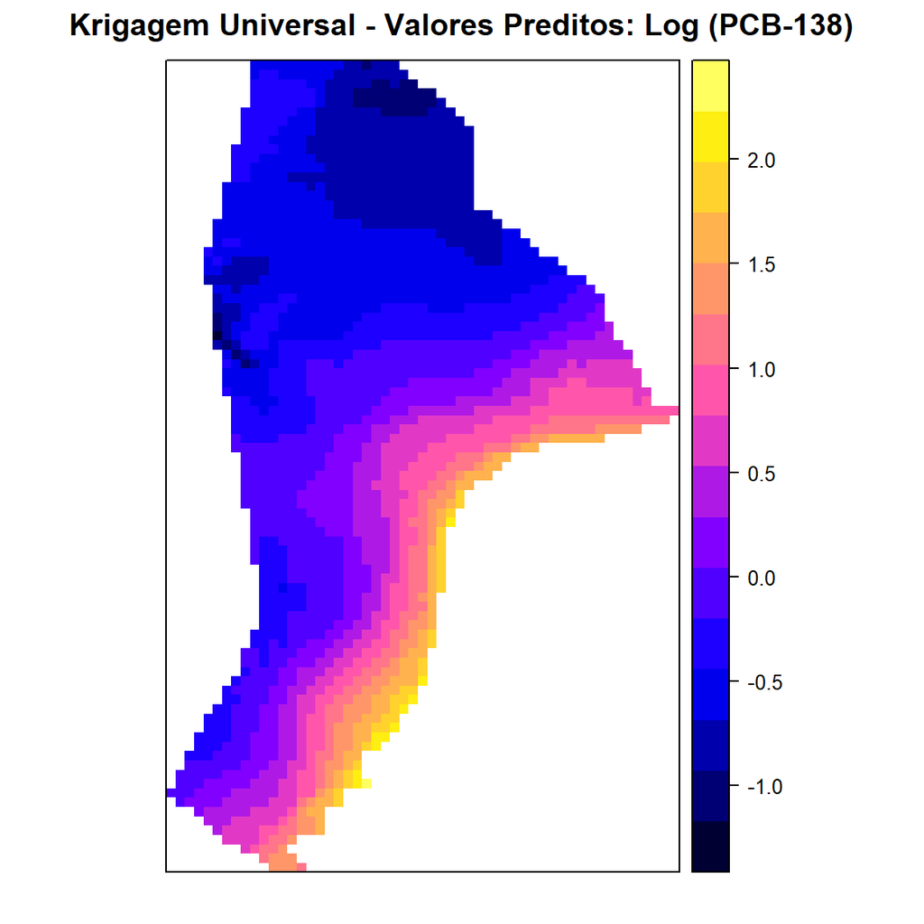

```r
p2pred <- spplot(dados_krigagem_universal["var1.pred"], main = "Krigagem Universal - Valores Preditos: Log (PCB-138)")
p2pred
```

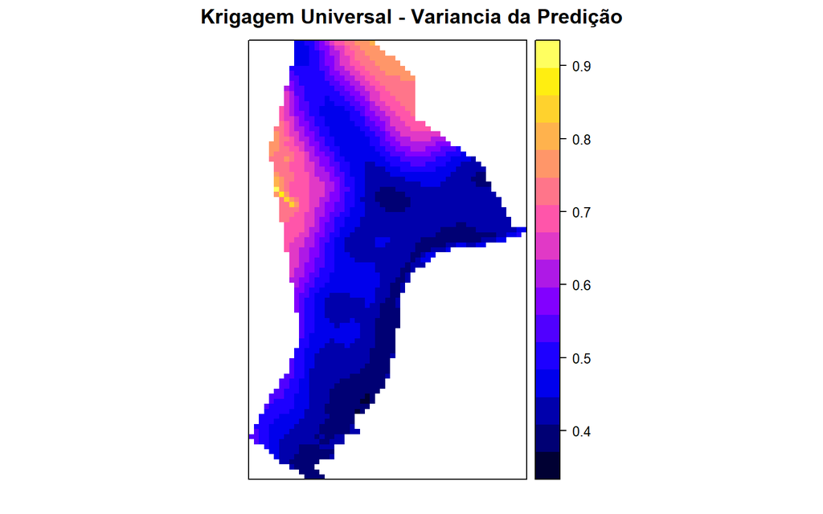

```r
p2var <- spplot(dados_krigagem_universal["var1.var"], main = "Krigagem Universal - Variancia da Predição")
p2var
```

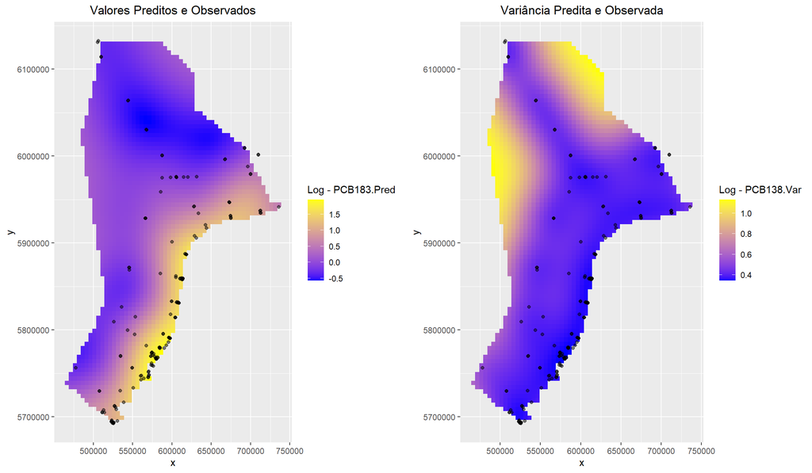

```r
grid.arrange(plot_media_ordinaria, plot_variancia_ordinaria, ncol=2)
```

Comparação dos dois modelos:

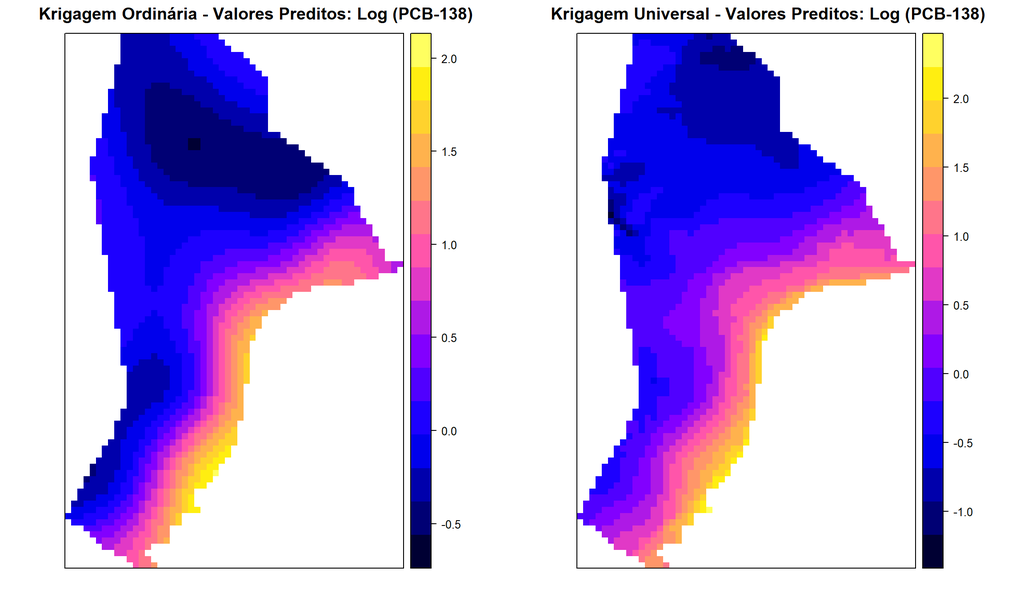

```r
grid.arrange(p1pred, p2pred, ncol=2)
```

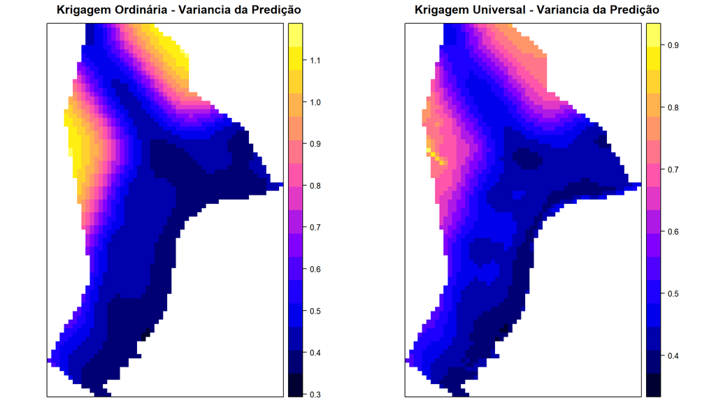

```r
grid.arrange(p1var, p2var, ncol=2)
```

## **3.3 Qualidade de Predição**

```r
erro_krigagem_universal <- krige.cv(log(PCB138) ~ depth + coast, df, ajuste_esf_variograma_com_covariavel)
mse_krigagem_universal <- round(sqrt(mean(erro_krigagem_universal$residual^2)), 7)
mse_krigagem_universal
```

```
## [1] 0.7493424
```

```r
erro_krigagem_ordinaria <- krige.cv(log(PCB138) ~ 1, df, fit.gau)
mse_krigagem_ordinaria <- round(sqrt(mean(erro_krigagem_ordinaria$residual^2)), 7)
mse_krigagem_ordinaria
```

```
## [1] 0.7627777
```

O modelo sem covariáveis apresenta um MSE um pouco maior se comparado ao modelo considerando as variáveis “depth” e “coast”.

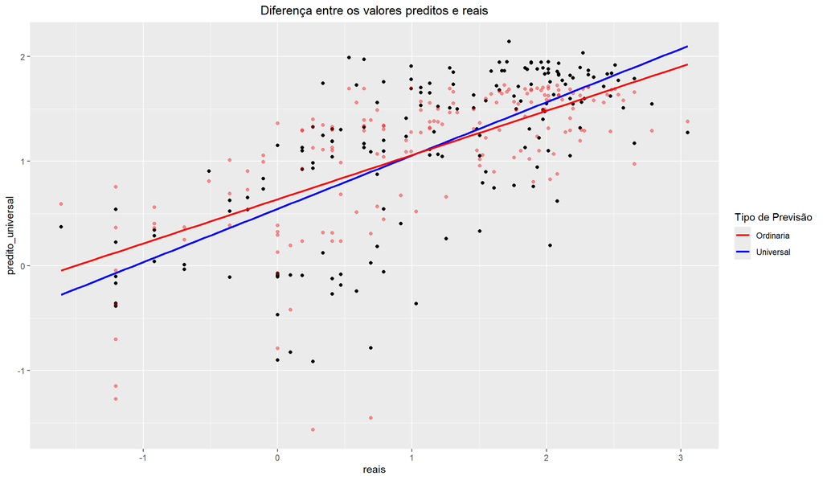

```r
valores_predidos_reais = data.frame(predito_universal=c(erro_krigagem_universal$var1.pred), predito_ordinaria =c(erro_krigagem_ordinaria$var1.pred), reais = c(log(df$PCB138)))

ggplot(valores_predidos_reais) +
  geom_point(aes(x=reais, y=predito_universal)) +
  geom_point(aes(x=reais, y=predito_ordinaria), col="red", alpha=0.4) +
  geom_smooth(aes(x=reais, y=predito_universal, color="Universal"), method="lm", se=FALSE) +  # Linha de tendência para predito_universal
  geom_smooth(aes(x=reais, y=predito_ordinaria, color="Ordinaria"), method="lm", se=FALSE) +  # Linha de tendência para predito_ordinaria
  ggtitle("Diferença entre os valores preditos e reais") +
  theme(plot.title = element_text(hjust = 0.5)) +
  scale_color_manual(name = "Tipo de Previsão", values = c("Universal" = "blue", "Ordinaria" = "red"))
```